# Project: Investigating the Medical Appointment No Shows dataset(The characteristics that determine between people that show up for Appointment and people that don't)

- Introduction
- Data Wrangling
- Exploratory Data Analysis
- Conclusions

## Introduction

> This dataset collects information from 100k medical appointments in Brazil and is focused on the question of whether or not patients show up for their appointment. A number of characteristics about the patient are included in each row.

> You can see more details about the 14 data's features in the table below:

[output not shown]

# Questions

### Main: What are the characteristics that surounds if a patient show up for appointment or not

> 1. What are the percentage of male and female that show up
> 2. What are the percentage of male and female that don't show up
> 3. How does Having a scholarship or not having one affects showing up rate
> 4. How does our independent features correlates wit each other and our dependent variables
> 5. what are the mean Age of people that show up and people that don't
> 6. What percentage of both genders showed up or not that are below and above the median age
> 7. Does havaing hypertension affectes showing up
> 8. How well does Age correlates with being hypertensive

```python
# import relevant libaries
import pandas as pd
import numpy as np
import matplotlib.pyplot as plt
import seaborn as sns
%matplotlib inline
```

## Data Wrangling

### General Properties

```python
# Load your data and print out a few lines. Perform operations to inspect data
#   types and look for instances of missing or possibly errant data.
df = pd.read_csv('noshowappointments-kagglev2-may-2016.csv')
df.head(3)
```

|  | PatientId | AppointmentID | Gender | ScheduledDay | AppointmentDay | Age | Neighbourhood | Scholarship | Hipertension | Diabetes | Alcoholism | Handcap | SMS_received | No-show |
| --- | --- | --- | --- | --- | --- | --- | --- | --- | --- | --- | --- | --- | --- | --- |
| 0 | 2.987250e+13 | 5642903 | F | 2016-04-29T18:38:08Z | 2016-04-29T00:00:00Z | 62 | JARDIM DA PENHA | 0 | 1 | 0 | 0 | 0 | 0 | No |
| 1 | 5.589978e+14 | 5642503 | M | 2016-04-29T16:08:27Z | 2016-04-29T00:00:00Z | 56 | JARDIM DA PENHA | 0 | 0 | 0 | 0 | 0 | 0 | No |
| 2 | 4.262962e+12 | 5642549 | F | 2016-04-29T16:19:04Z | 2016-04-29T00:00:00Z | 62 | MATA DA PRAIA | 0 | 0 | 0 | 0 | 0 | 0 | No |

```python
#investigating the shape of our data. How many rows and columns(rows, columns)
print('This dataset contains {} rows and {} columns'.format(df.shape[0],df.shape[1]))
```

```
This dataset contains 110527 rows and 14 columns
```

```python
#Lets investigate for missing Values in our data
print(df.isnull().any()), print('*************************************'), print(df.isnull().sum())
```

```
PatientId         False
AppointmentID     False
Gender            False
ScheduledDay      False
AppointmentDay    False
Age               False
Neighbourhood     False
Scholarship       False
Hipertension      False
Diabetes          False
Alcoholism        False
Handcap           False
SMS_received      False
No-show           False
dtype: bool
PatientId         0
AppointmentID     0
Gender            0
ScheduledDay      0
AppointmentDay    0
Age               0
Neighbourhood     0
Scholarship       0
Hipertension      0
Diabetes          0
Alcoholism        0
Handcap           0
SMS_received      0
No-show           0
dtype: int64
```

```
(None, None, None)
```

Our data has no missing value

```python
#Let's explore more to see if we have duplicates
df.duplicated().any() #returns False if no duplicates
```

```
False
```

```python
# Investigating the data types of non-null columns
df.info()
```

```
<class 'pandas.core.frame.DataFrame'>
RangeIndex: 110527 entries, 0 to 110526
Data columns (total 14 columns):
PatientId         110527 non-null float64
AppointmentID     110527 non-null int64
Gender            110527 non-null object
ScheduledDay      110527 non-null object
AppointmentDay    110527 non-null object
Age               110527 non-null int64
Neighbourhood     110527 non-null object
Scholarship       110527 non-null int64
Hipertension      110527 non-null int64
Diabetes          110527 non-null int64
Alcoholism        110527 non-null int64
Handcap           110527 non-null int64
SMS_received      110527 non-null int64
No-show           110527 non-null object
dtypes: float64(1), int64(8), object(5)
memory usage: 11.8+ MB
```

```python
#investigating the summary statistics of our numeric columns
df.describe()
```

|  | PatientId | AppointmentID | Age | Scholarship | Hipertension | Diabetes | Alcoholism | Handcap | SMS_received |
| --- | --- | --- | --- | --- | --- | --- | --- | --- | --- |
| count | 1.105270e+05 | 1.105270e+05 | 110527.000000 | 110527.000000 | 110527.000000 | 110527.000000 | 110527.000000 | 110527.000000 | 110527.000000 |
| mean | 1.474963e+14 | 5.675305e+06 | 37.088874 | 0.098266 | 0.197246 | 0.071865 | 0.030400 | 0.022248 | 0.321026 |
| std | 2.560949e+14 | 7.129575e+04 | 23.110205 | 0.297675 | 0.397921 | 0.258265 | 0.171686 | 0.161543 | 0.466873 |
| min | 3.921784e+04 | 5.030230e+06 | -1.000000 | 0.000000 | 0.000000 | 0.000000 | 0.000000 | 0.000000 | 0.000000 |
| 25% | 4.172614e+12 | 5.640286e+06 | 18.000000 | 0.000000 | 0.000000 | 0.000000 | 0.000000 | 0.000000 | 0.000000 |
| 50% | 3.173184e+13 | 5.680573e+06 | 37.000000 | 0.000000 | 0.000000 | 0.000000 | 0.000000 | 0.000000 | 0.000000 |
| 75% | 9.439172e+13 | 5.725524e+06 | 55.000000 | 0.000000 | 0.000000 | 0.000000 | 0.000000 | 0.000000 | 1.000000 |
| max | 9.999816e+14 | 5.790484e+06 | 115.000000 | 1.000000 | 1.000000 | 1.000000 | 1.000000 | 4.000000 | 1.000000 |

### Data Cleaning

##### Drop columns not useful for our analysis, Drops rows with wrong observations, split the dataset into two with the no-show column(1: no-show == yes, 2: no-show == no) and use it as filter on the main dataframe.

```python
df.columns
cols = ['PatientId', 'AppointmentID','ScheduledDay',
       'AppointmentDay','Neighbourhood']
df.drop(columns=cols,axis=1,inplace=True)
```

```python
# After discussing the structure of the data and any problems that need to be
#   cleaned, perform those cleaning steps in the second part of this section.
df.head(5)
```

|  | Gender | Age | Scholarship | Hipertension | Diabetes | Alcoholism | Handcap | SMS_received | No-show |
| --- | --- | --- | --- | --- | --- | --- | --- | --- | --- |
| 0 | F | 62 | 0 | 1 | 0 | 0 | 0 | 0 | No |
| 1 | M | 56 | 0 | 0 | 0 | 0 | 0 | 0 | No |
| 2 | F | 62 | 0 | 0 | 0 | 0 | 0 | 0 | No |
| 3 | F | 8 | 0 | 0 | 0 | 0 | 0 | 0 | No |
| 4 | F | 56 | 0 | 1 | 1 | 0 | 0 | 0 | No |

```python
#remove incorect observation row from Age
incorrect_row = df.query('Age < 0').index
df.drop(incorrect_row,axis=0,inplace=True)
```

```python
#rename colums and convert them to lowercase
df.rename(columns=lambda x: x.strip().lower().replace("-", "_"), inplace=True)
df.columns
```

```
Index(['gender', 'age', 'scholarship', 'hipertension', 'diabetes',
       'alcoholism', 'handcap', 'sms_received', 'no_show'],
      dtype='object')
```

```python
#remap values in Gender and No-show to make them consistent
df.gender = df.gender.map({'F':'female','M':'male'})

df.no_show = df.no_show.map({'No':0,'Yes':1})
df.head(2)
```

|  | gender | age | scholarship | hipertension | diabetes | alcoholism | handcap | sms_received | no_show |
| --- | --- | --- | --- | --- | --- | --- | --- | --- | --- |
| 0 | female | 62 | 0 | 1 | 0 | 0 | 0 | 0 | 0 |
| 1 | male | 56 | 0 | 0 | 0 | 0 | 0 | 0 | 0 |

```python
df.head(3)
```

|  | gender | age | scholarship | hipertension | diabetes | alcoholism | handcap | sms_received | no_show |
| --- | --- | --- | --- | --- | --- | --- | --- | --- | --- |
| 0 | female | 62 | 0 | 1 | 0 | 0 | 0 | 0 | 0 |
| 1 | male | 56 | 0 | 0 | 0 | 0 | 0 | 0 | 0 |
| 2 | female | 62 | 0 | 0 | 0 | 0 | 0 | 0 | 0 |

```python
show_up = df.no_show == True
non_show = df.no_show == False
```

## Exploratory Data Analysis

### Research Question 1

> 1. What are the percentage of male and female that show up
> 2. What are the percentage of male and female that don't show up

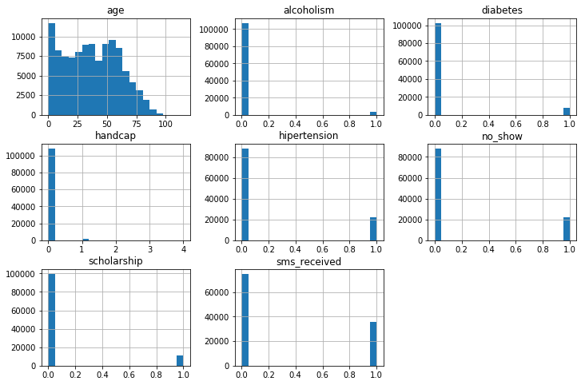

```python
# Use this, and more code cells, to explore your data. Don't forget to add
#   Markdown cells to document your observations and findingsdf
df.hist(figsize=(12,8), bins=20);
```

```python
#First lets evaluate the total number of mails and females in our data
df.gender.value_counts()
```

```
female    71839
male      38687
Name: gender, dtype: int64
```

```python
#percentage of male and female that show up
print('the total number of male and female that showed up is : {} '.format(df[show_up].gender.value_counts().sum()))
print('the percentage of male that showed up is : {:.3f} that is {} in total'.format(df[show_up].gender.value_counts(normalize=True)[1],df[show_up].gender.value_counts()[1]))

print('the percentage of female that showed up is : {:.3f} that is {} in total'.format(df[show_up].gender.value_counts(normalize=True)[0],df[show_up].gender.value_counts()[0]))
```

```
the total number of male and female that showed up is : 22319
the percentage of male that showed up is : 0.346 that is 7725 in total
the percentage of female that showed up is : 0.654 that is 14594 in total
```

```python
#percentage of male and female that didn't show up
print('the total number of male and female that didn\'t showed up is : {} '.format(df[non_show].gender.value_counts().sum()))
print('the percentage of male that didn\'t showed up is : {:.3f} that is {} in total'.format(df[non_show].gender.value_counts(normalize=True)[1],df[non_show].gender.value_counts()[1]))

print('the percentage of female that didn\'t showed up is : {:.3f} that is {} in total'.format(df[non_show].gender.value_counts(normalize=True)[0],df[non_show].gender.value_counts()[1]))
```

```
the total number of male and female that didn't showed up is : 88207
the percentage of male that didn't showed up is : 0.351 that is 30962 in total
the percentage of female that didn't showed up is : 0.649 that is 30962 in total
```

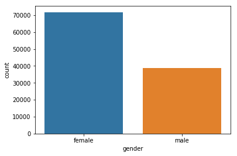

```python
#lets plot the distribution of Gender in the data
sns.countplot(x="gender", data=df)
```

We can clearly see that they are more females than male that booked scheduled appointment in our dataset

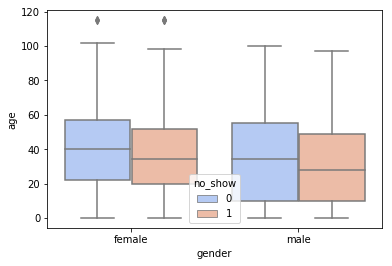

```python
# lets investigate the gender column further with respect to their ages  and see their show status
sns.boxplot(x="gender",y="age",hue="no_show",data=df, palette="coolwarm");
```

## Research question 2

> 1. How does Having a scholarship or not having one affects showing up rate

```python
df.groupby('scholarship')['no_show'].value_counts()
```

```
scholarship  no_show
0            0          79924
             1          19741
1            0           8283
             1           2578
Name: no_show, dtype: int64
```

```
Text(0.5,1,'Scholarship correlation with how people show up')
```

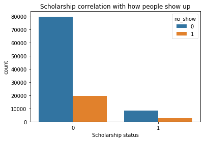

```python
#Lets confirm this visually
sns.countplot('scholarship', data=df, hue='no_show')
#df.scholarship.value_counts().plot(kind='bar')
plt.xlabel('Scholarship status')
plt.title('Scholarship correlation with how people show up')
```

### Research Question 3

> 1. How does our independent features correlates with each other and our dependent variables

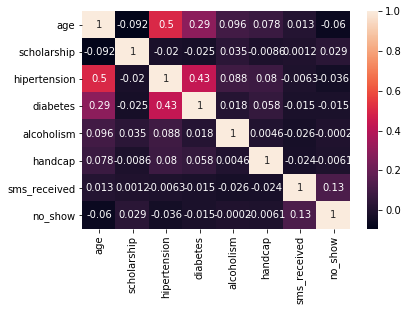

```python
#lets visualize the correlation with a heatmap
corr = df.corr()
sns.heatmap(corr,annot=True,cbar=True, linecolor='r')
```

You can see that Age is strongly correlated with hipertension which can be considered to be through because as people get older, they tend to become hypertensive. Also hyperyension aslo have a positive correlation with diabetes.

```python
#Let us investigate further and see which feature correlates well with our dependent variable no_show
corr['no_show']
```

```
age            -0.060327
scholarship     0.029134
hipertension   -0.035704
diabetes       -0.015181
alcoholism     -0.000197
handcap        -0.006077
sms_received    0.126428
no_show         1.000000
Name: no_show, dtype: float64
```

```
Text(0.5,0,'No_s')
```

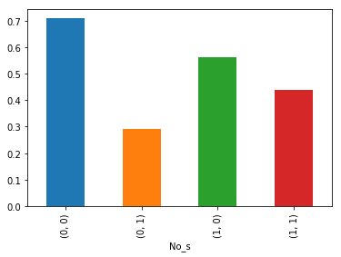

```python
#sns.boxplot(x="no_show",y="sms_received",hue="no_show",data=df, palette="coolwarm");
df.groupby('no_show')['sms_received'].value_counts(normalize=True).plot('bar');
plt.xlabel('No_s')
```

## Research question 4

> 1. what are the mean Age of people that show up and people that don't
> 2. What percentage of both genders showed up or not that are below and above the median age

```python
#Lets filter our dataset and see the mean age of both genders that showed up and the ones that didn't
print('the average age group that showed up is between: {:.0f} years old'.format(df[show_up].age.mean()))
print('the average age group that didn\'t showed up is between: {:.0f} years old'.format(df[non_show].age.mean()))
```

```
the average age group that showed up is between: 34 years old
the average age group that didn't showed up is between: 38 years old
```

## let us look at the distrubtion of ages of people that show up or not to confirm further

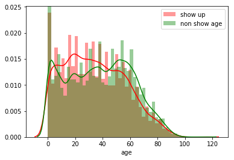

```python
sns.distplot(df[show_up].age, color='r',label='show up');
sns.distplot(df[non_show].age,color='g', norm_hist=True, label='non show age');
plt.legend()
```

### let us take the analysis further by filtering with the median age value to see how genders below median age showed up or not as compared to those above

```python
median_age = df.age.median()
print('There are {} females and {} males in our data that showed up'.format(df[show_up].gender.value_counts()[0],
      df[show_up].gender.value_counts()[1]))
print('BUT')
print('{} females and {} males are number of people below {} median age that showed up'.format(df[show_up].query('age <= {}'.format(median_age))['gender'].value_counts()[0],
                                                                                     df[show_up].query('age <= {}'.format(median_age))['gender'].value_counts()[1],
                                                                                     median_age))
```

```
There are 14594 females and 7725 males in our data that showed up
BUT
7978 females and 4783 males are number of people below 37.0 median age that showed up
```

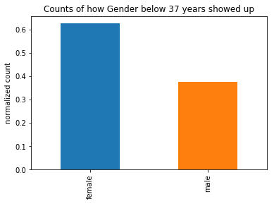

```python
df[show_up].query('age <= {}'.format(median_age))['gender'].value_counts(normalize=True).plot(kind='bar');
plt.title('Counts of how Gender below {:.0f} years showed up'.format(median_age));
plt.ylabel('normalized count');
```

It appears that female below 37 years show up more than male. You can agree with this finding because generally women are more concerned about the health more than men

```python
print('There are {} females and {} males in our data that showed up'.format(df[show_up].gender.value_counts()[0],
      df[show_up].gender.value_counts()[1]))
print('BUT')
print('{} females and {} males are number of people above {} median age that showed up'.format(df[show_up].query('age >= {}'.format(median_age))['gender'].value_counts()[0],
                                                                                     df[show_up].query('age >= {}'.format(median_age))['gender'].value_counts()[1],
                                                                                     median_age))
```

```
There are 14594 females and 7725 males in our data that showed up
BUT
6837 females and 3038 males are number of people above 37.0 median age that showed up
```

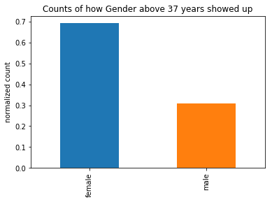

```python
#Also for the count of genders above the median age that showed up
df[show_up].query('age >= {}'.format(median_age))['gender'].value_counts(normalize=True).plot(kind='bar');
plt.title('Counts of how Gender above {:.0f} years showed up'.format(median_age));
plt.ylabel('normalized count');
```

## There are 14594 females and 7725 males in our data that showed up

> `6837 females`, `3038 males` are above `37 years` old while `7978 females` and `4783 males` are below `37 years` old.

**Women have the greater number of observation in our dataset so it is likely they will show up more than men**

```python
print('There are {} females and {} males in our data that didn\'t up'.format(df[non_show].gender.value_counts()[0],
      df[non_show].gender.value_counts()[1]))
print('{} are females, {} are males below {} median age'.format(df[non_show].query('age <= {}'.format(median_age))['gender'].value_counts()[0],
                                                                                     df[non_show].query('age <= {}'.format(median_age))['gender'].value_counts()[1],
                                                                                     median_age))
```

```
There are 57245 females and 30962 males in our data that didn't up
26798 are females, 16557 are males below 37.0 median age
```

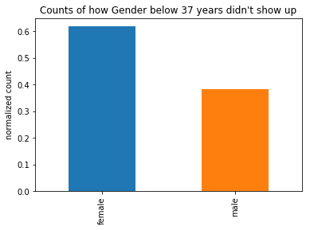

```python
#let us plot this visually
df[non_show].query('age <= {}'.format(median_age))['gender'].value_counts(normalize=True).plot(kind='bar');
plt.title('Counts of how Gender below {:.0f} years didn\'t show up'.format(median_age));
plt.ylabel('normalized count');
```

```
31340 are females, 14728 are males above 37.0 median age
```

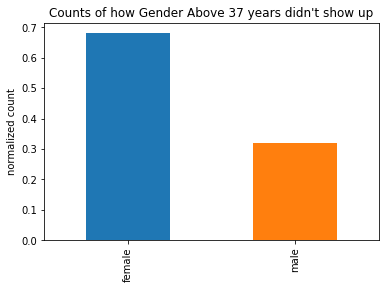

```python
print('{} are females, {} are males above {} median age'.format(df[non_show].query('age >= {}'.format(median_age))['gender'].value_counts()[0],
                                                                                     df[non_show].query('age >= {}'.format(median_age))['gender'].value_counts()[1],
                                                                                     median_age))

df[non_show].query('age >= {}'.format(median_age))['gender'].value_counts(normalize=True).plot(kind='bar')
plt.title('Counts of how Gender Above {:.0f} years didn\'t show up'.format(median_age));
plt.ylabel('normalized count');
```

## There are 57245 females and 30962 males in our data that didn't show up

> 26798 females and 16557 males are below `37 years` old while 31340 females and 14728 males are above `37 years` old

## Lets us see how being hypertensive determines if a patient will show up or not

```python
hipertensive = df.query('hipertension == 1')
non_hipertensive = df.query('hipertension == 0')
```

```python
hipertensive.groupby('hipertension')['no_show'].value_counts()
```

```
hipertension  no_show
1             0          18029
              1           3772
Name: no_show, dtype: int64
```

```python
non_hipertensive.groupby('hipertension')['no_show'].value_counts()
```

```
hipertension  no_show
0             0          70178
              1          18547
Name: no_show, dtype: int64
```

```python
#Lets check the correlation between hipertensive patients and age
corr['hipertension']['age']
```

```
0.50458562241670235
```

> they seem to have an average positive correlation. lets explore further

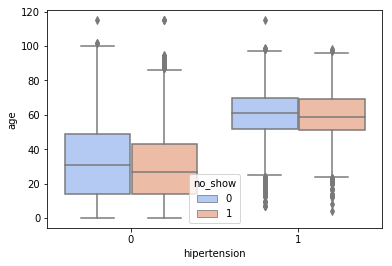

```python
# plt.stackplot(x='hipertension',data = df[show_up])
sns.boxplot(x="hipertension",y="age",hue="no_show",data=df, palette="coolwarm");
```

It appears that as a patient grow older they are more likely to develop hypertension From this plot you can tell that people with hypertension have ages between 55years to 70years

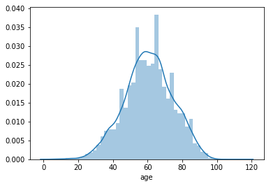

```python
sns.distplot(hipertensive['age']);
```

> This plot confirms how our age are distributed for patients with hypertension. The older people are likely to be hyternsive than young people

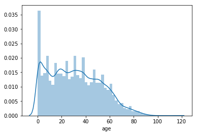

```python
sns.distplot(non_hipertensive['age']);
```

> This plot for non hipertensive patients is skewed to the right showing that young people are unlikey to have hipertension

```python
hipertensive['gender'].value_counts()
```

```
female    15339
male       6462
Name: gender, dtype: int64
```

> more females have hypertension than males.

## steps i took for this analysis.

1. i divided the dataset into two. One for those that showed up and the second for those that didn't show up and used it as a filter to get inisghts.
2. i plotted visualization to back up any insight i dicover to better communicate my findings ### let me reiterate my questions and then communicate my findings
3. What are the percentage of male and female that show up

   > > Findings: In general more females are likely to show up than males
4. What are the percentage of male and female that don't show up

   > > finding: the perentage of females that didn't show up is greater than that of males
5. How does Having a scholarship or not having one affects showing up rate

   > > findings: having a scholarship doesn't determine if a patient show or not as those patetients without scholarship show up more
6. How does our independent features correlates wit each other and our dependent variables

   > > finding: Most of the independent variable is negatively correlated with our dependent variable Age feature has a slight positive correlation with hipertension feature
7. what are the mean Age of people that show up and people that don't

   > > findings: it has a positive correlation with age. The older you get the more hypertensive you are likely to become

## Submitting your Project

> Before you submit your project, you need to create a .html or .pdf version of this notebook in the workspace here. To do that, run the code cell below. If it worked correctly, you should get a return code of 0, and you should see the generated .html file in the workspace directory (click on the orange Jupyter icon in the upper left).

> Alternatively, you can download this report as .html via the **File** > **Download as** submenu, and then manually upload it into the workspace directory by clicking on the orange Jupyter icon in the upper left, then using the Upload button.

> Once you've done this, you can submit your project by clicking on the "Submit Project" button in the lower right here. This will create and submit a zip file with this .ipynb doc and the .html or .pdf version you created. Congratulations!

```python
from subprocess import call
call(['python', '-m', 'nbconvert', 'Investigate_a_Dataset.ipynb'])
```